# Making interpretations with Moons data and analyzing the properties of the Poisson and the Binomial distribution

Hinami Nishi

It seems reasonable to assume that the `mass` of a planet should be related to the cube of the `diameter` as they are (mostly) very close to being spheres.

# 1 MOONS DATA

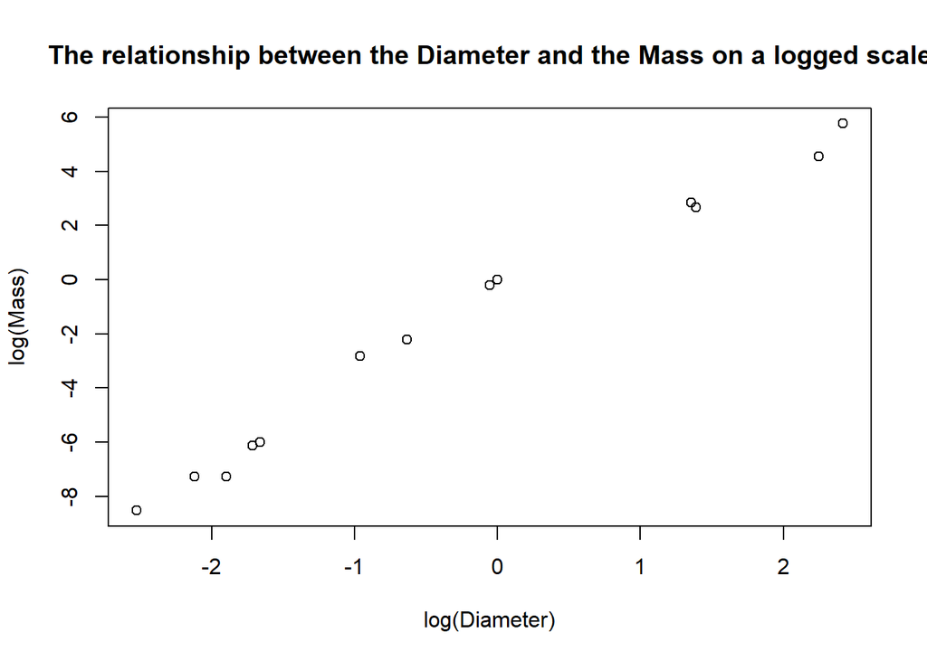

```r
Moons.df <- read.csv("Moons.csv")
plot(log(Mass)~log(Diameter), data = Moons.df)
title("The relationship between the Diameter and the Mass on a logged scale")
```

> WE CAN OBVIOUSLY SEE
- we see a positive linear relationship
- *“The Mass and the diameter^3 is related as they’re close to being sphere”.* If this is true, then we expect for the mass and the diameter^3 to have a power-law relationship, so we know that when we log it, it will present a linear relationship. This is consistent with the observations: We see a positive linear relationship between the Mass of a dwarf planet and the Diameter of it after applying the log-link function.

> A simple linear regression model fitted to data these

```r
moon_fit <- lm(log(Mass)~ log(Diameter),
               data = Moons.df)

summary(moon_fit)
```

```
##
## Call:
## lm(formula = log(Mass) ~ log(Diameter), data = Moons.df)
##
## Residuals:
##     Min      1Q  Median      3Q     Max
## -0.8864 -0.2943 -0.2511  0.5663  0.9767
##
## Coefficients:
##               Estimate Std. Error t value Pr(>|t|)
## (Intercept)    -0.9767     0.1890  -5.167  0.00031 ***
## log(Diameter)   2.8471     0.1134  25.117 4.59e-11 ***
## ---
## Signif. codes:  0 '***' 0.001 '**' 0.01 '*' 0.05 '.' 0.1 ' ' 1
##
## Residual standard error: 0.6689 on 11 degrees of freedom
## Multiple R-squared:  0.9829, Adjusted R-squared:  0.9813
## F-statistic: 630.8 on 1 and 11 DF,  p-value: 4.585e-11
```

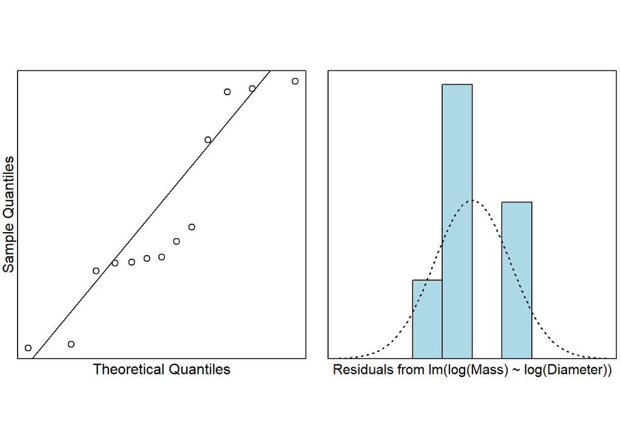

```r
normcheck(moon_fit)
```

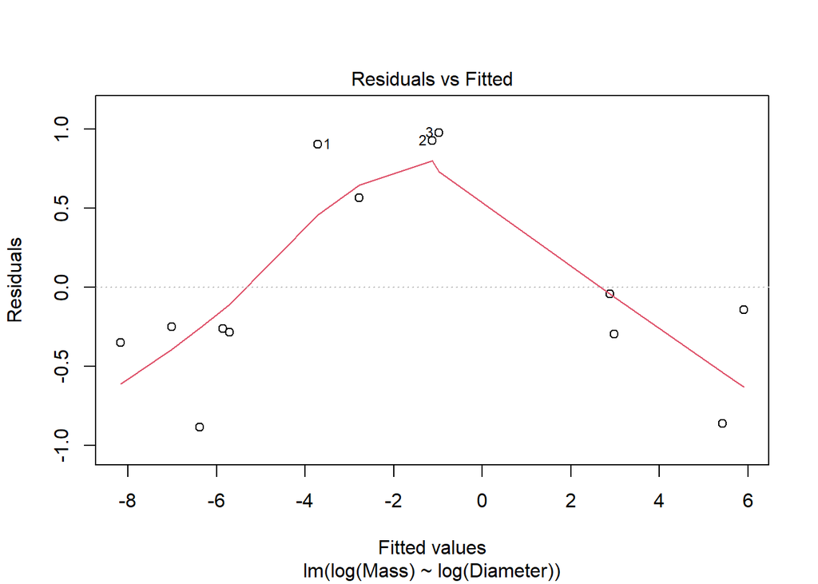

```r
plot(moon_fit, which = 1)
```

1. normality
- Although, we might have concern with the normality assumption as we see some asymmetric features in the residuals from the fit, we are not concerned.
2. Variability
- We have 98% of variability explained by the model, suggesting it being a good fit.
3. Residual plot:
- A quadratic curvature in the residual plot is displayed, but because the scale is so small, we’re not too concerned. Further diagnostic tests may be used to check for this, but this will not be of concern.

> Visualising the predicition with upper and lower 95% bounds

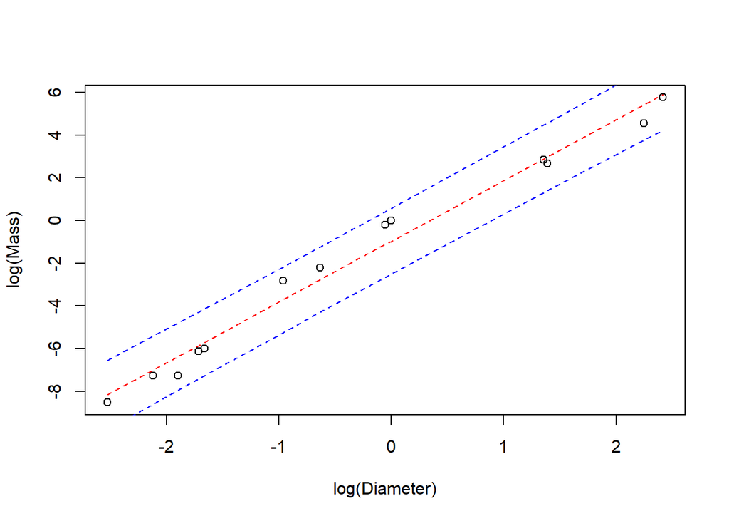

```r
moon_fit <- lm(log(Mass) ~ log(Diameter), data = Moons.df)

plot(log(Mass) ~ log(Diameter), data = Moons.df)

x = sort(Moons.df$Diameter)
preds = predict(moon_fit,
                newdata = data.frame(Diameter = x),
                interval = "prediction",
                level = 0.95)

lines(log(x), preds[, "upr"], col = "blue", lty = 2)
lines(log(x), preds[, "fit"], col = "red", lty = 2)
lines(log(x), preds[, "lwr"], col = "blue", lty = 2)
```

> Testing the hypothesis this that planet’s or dwarf planet’s mass is related to the cube of its diameter (assuming that the SLR model fitted above is adequate.)

```r
summary(moon_fit)
```

```
##
## Call:
## lm(formula = log(Mass) ~ log(Diameter), data = Moons.df)
##
## Residuals:
##     Min      1Q  Median      3Q     Max
## -0.8864 -0.2943 -0.2511  0.5663  0.9767
##
## Coefficients:
##               Estimate Std. Error t value Pr(>|t|)
## (Intercept)    -0.9767     0.1890  -5.167  0.00031 ***
## log(Diameter)   2.8471     0.1134  25.117 4.59e-11 ***
## ---
## Signif. codes:  0 '***' 0.001 '**' 0.01 '*' 0.05 '.' 0.1 ' ' 1
##
## Residual standard error: 0.6689 on 11 degrees of freedom
## Multiple R-squared:  0.9829, Adjusted R-squared:  0.9813
## F-statistic: 630.8 on 1 and 11 DF,  p-value: 4.585e-11
```

```r
t_val <- (2.8471 - 3)/0.1134
2*pt(t_val, 11)
```

```
## [1] 0.2046614
```

Yes, as we **don’t have evidence** (p-value $\approx$ 0.2046614 ) that the planet’s or dwarf planet’s mass related to the cube of its diameter (3) is significantly different to the estimate 2.8471. We say it’s alright to use 3 as an estimate.

### 1.0.1 Proving if what the data we have is consistent with the information about the density of plantes

It is known that [the inner planets are rocky and so have higher `density`, followed by lower density gas giants and then, ice giants which have slightly higher density compared to the gas giant planets.](https://www.universetoday.com/36935/density-of-the-planets/). Hence, we will investigate if what we see in out data is consisten with these claims.

```r
#Creating the new df
moons.df <- Moons.df %>%
  mutate(Density = Mass/(Diameter^3) )
moons.df
```

```
##         Name Distance Diameter     Mass Moons   Density
## 1   Mercury      0.39    0.382   0.0600     0 1.0763690
## 2     Venus      0.72    0.949   0.8200     0 0.9594342
## 3      Earth     1.00    1.000   1.0000     1 1.0000000
## 4      Mars      1.52    0.532   0.1100     2 0.7305632
## 5     Ceres      2.75    0.080   0.0002     0 0.3906250
## 6   Jupiter      5.20   11.209 317.8000    64 0.2256593
## 7    Saturn      9.54    9.449  95.2000    62 0.1128442
## 8    Uranus     19.22    4.007  14.6000    27 0.2269315
## 9   Neptune     30.06    3.883  17.2000    13 0.2937827
## 10    Pluto     39.50    0.180   0.0022     4 0.3772291
## 11   Haumea     43.35    0.150   0.0007     2 0.2074074
## 12 Makemake     45.80    0.120   0.0007     0 0.4050926
## 13     Eris     67.70    0.190   0.0025     1 0.3644846
```

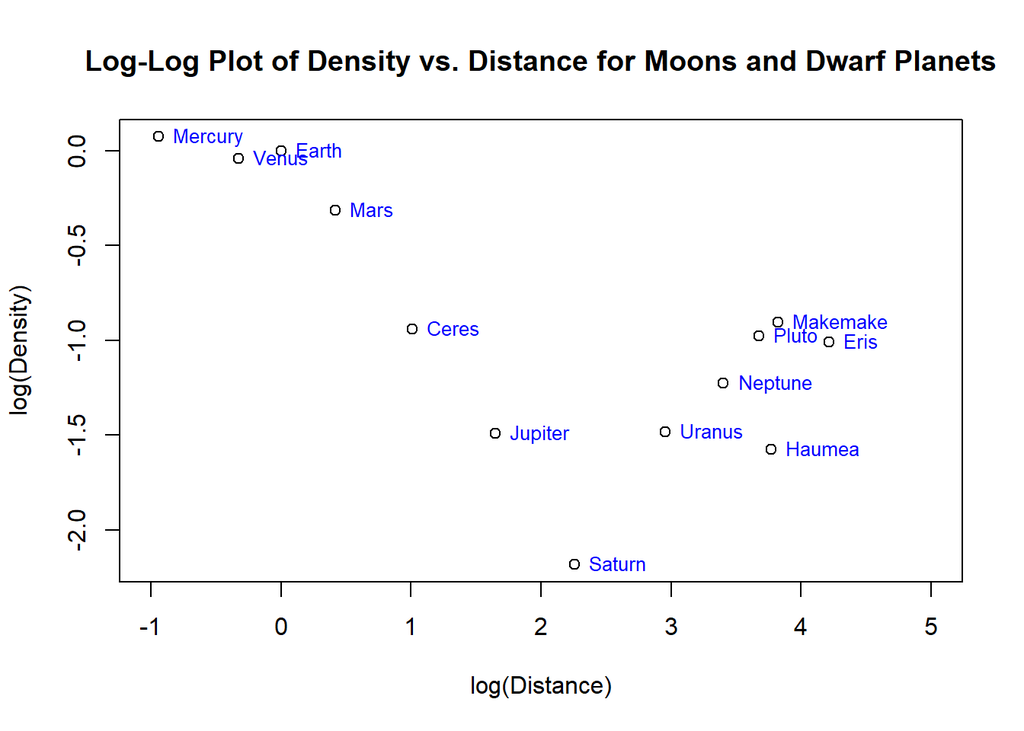

```r
#Plotting on log-log scale and superimposing the names of these plants and dwarf planets.
plot(log(Density) ~ log(Distance), data = moons.df, xlim = c(-1, 5))

# Add text labels for moon/dwarf planet names
text(log(moons.df$Distance), log(moons.df$Density),labels = moons.df$Name,
     pos = 4, cex = 0.8, col = "blue")
title("Log-Log Plot of Density vs. Distance for Moons and Dwarf Planets")
```

Yes, it’s consistent with the claims.

### 1.0.2 Finding an appropriate model

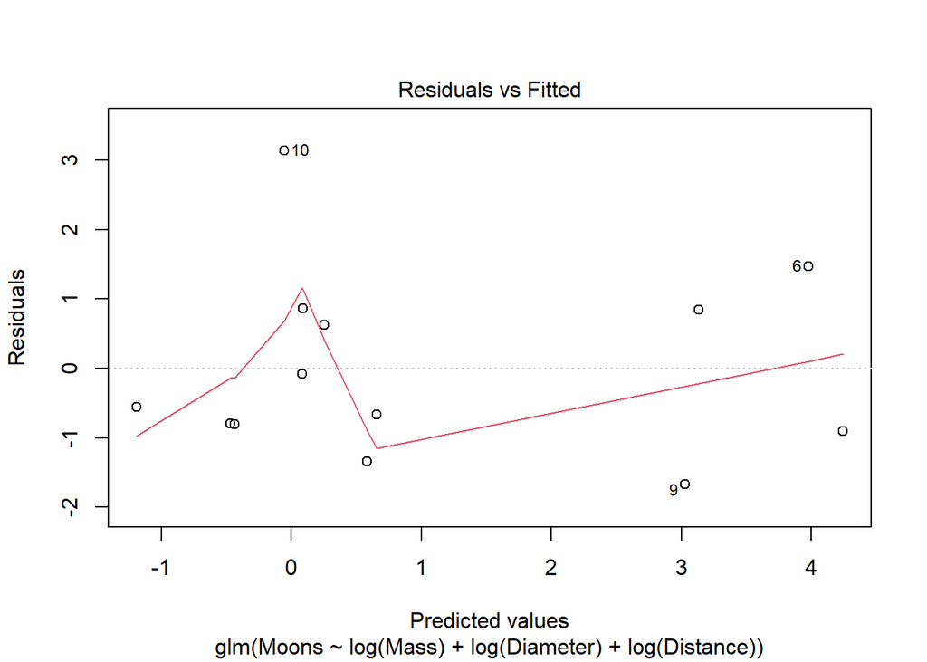

```r
#Main effects
moons.gfit <- glm(Moons ~ log(Mass) + log(Diameter) + log(Distance),
                  family = "poisson", data = moons.df)

plot(moons.gfit, which = 1 )
```

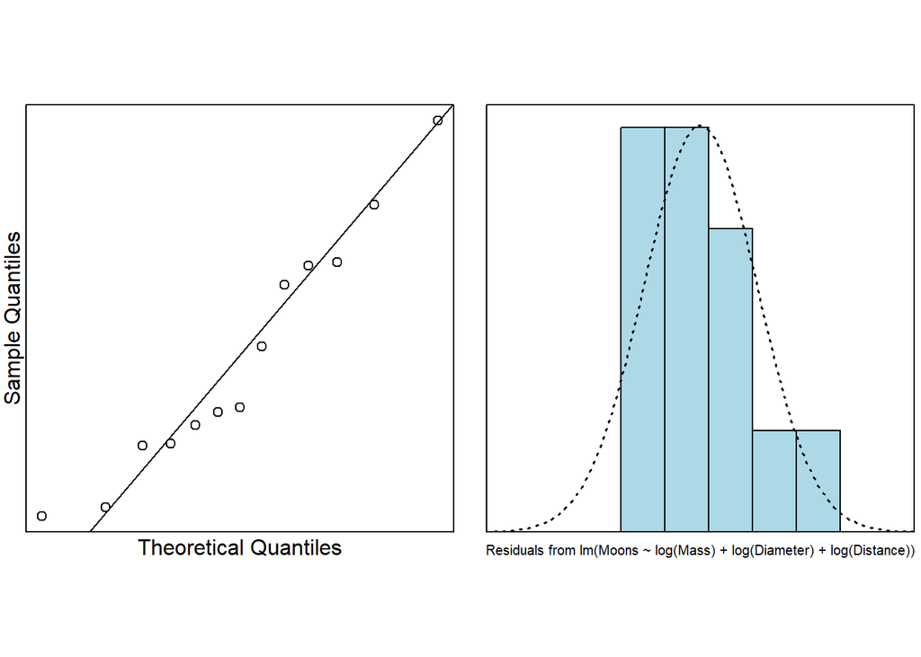

```r
normcheck(moons.gfit)
```

```r
summary(moons.gfit )
```

```
##
## Call:
## glm(formula = Moons ~ log(Mass) + log(Diameter) + log(Distance),
##     family = "poisson", data = moons.df)
##
## Deviance Residuals:
##     Min       1Q   Median       3Q      Max
## -1.8933  -1.1191  -0.7332   0.7780   2.3294
##
## Coefficients:
##               Estimate Std. Error z value Pr(>|z|)
## (Intercept)     0.6536     0.3494   1.871   0.0614 .
## log(Mass)      -0.5162     0.2179  -2.369   0.0179 *
## log(Diameter)   2.5206     0.5728   4.400 1.08e-05 ***
## log(Distance)   0.1236     0.1144   1.080   0.2800
## ---
## Signif. codes:  0 '***' 0.001 '**' 0.01 '*' 0.05 '.' 0.1 ' ' 1
##
## (Dispersion parameter for poisson family taken to be 1)
##
##     Null deviance: 388.253  on 12  degrees of freedom
## Residual deviance:  20.435  on  9  degrees of freedom
## AIC: 62.451
##
## Number of Fisher Scoring iterations: 5
```

```r
#We see that we need some adjustments for this model.
```

> Finding the best model:

```r
#Do we've over-dispersion?
summary(moons.gfit)
```

```
##
## Call:
## glm(formula = Moons ~ log(Mass) + log(Diameter) + log(Distance),
##     family = "poisson", data = moons.df)
##
## Deviance Residuals:
##     Min       1Q   Median       3Q      Max
## -1.8933  -1.1191  -0.7332   0.7780   2.3294
##
## Coefficients:
##               Estimate Std. Error z value Pr(>|z|)
## (Intercept)     0.6536     0.3494   1.871   0.0614 .
## log(Mass)      -0.5162     0.2179  -2.369   0.0179 *
## log(Diameter)   2.5206     0.5728   4.400 1.08e-05 ***
## log(Distance)   0.1236     0.1144   1.080   0.2800
## ---
## Signif. codes:  0 '***' 0.001 '**' 0.01 '*' 0.05 '.' 0.1 ' ' 1
##
## (Dispersion parameter for poisson family taken to be 1)
##
##     Null deviance: 388.253  on 12  degrees of freedom
## Residual deviance:  20.435  on  9  degrees of freedom
## AIC: 62.451
##
## Number of Fisher Scoring iterations: 5
```

```r
1-pchisq(20.435, 9 ) # we've a small pval, so we've concern with the Poisson model
```

```
## [1] 0.01540965
```

```r
moons.gfit <- glm(Moons ~ log(Mass) + log(Diameter) + log(Distance),
                  family = "quasipoisson",
                  data = moons.df)
```

```r
#Check for main effects
summary(moons.gfit) #remove distance
```

```
##
## Call:
## glm(formula = Moons ~ log(Mass) + log(Diameter) + log(Distance),
##     family = "quasipoisson", data = moons.df)
##
## Deviance Residuals:
##     Min       1Q   Median       3Q      Max
## -1.8933  -1.1191  -0.7332   0.7780   2.3294
##
## Coefficients:
##               Estimate Std. Error t value Pr(>|t|)
## (Intercept)     0.6536     0.5378   1.215   0.2552
## log(Mass)      -0.5162     0.3355  -1.539   0.1583
## log(Diameter)   2.5206     0.8818   2.859   0.0188 *
## log(Distance)   0.1236     0.1761   0.702   0.5005
## ---
## Signif. codes:  0 '***' 0.001 '**' 0.01 '*' 0.05 '.' 0.1 ' ' 1
##
## (Dispersion parameter for quasipoisson family taken to be 2.369642)
##
##     Null deviance: 388.253  on 12  degrees of freedom
## Residual deviance:  20.435  on  9  degrees of freedom
## AIC: NA
##
## Number of Fisher Scoring iterations: 5
```